# Reproducible Research: Peer Assessment 1

Julian Carrillo

28/8/2020

## Resumen de analisis al conjunto de datos.

# 1. Código para leer en el conjunto de datos y/o procesar los datos.

El repositorio que fue dado, se clonó y en este se encuentran los datos en un archivo .zip, así que esa carpeta será nuestro espacio de trabajo. Los datos son descomprimidos, leidos y la columna date es convertida a tipo Date. Ademas de cargar librerias necesarias para el desarrollo de la actividad.

```r
library(ggplot2)
library(dplyr)
wd=getwd()
unzip(zipfile = "activity.zip", exdir = wd)
data=read.csv("activity.csv")
#La columna "date" se conviertea tipo Date.
data$date=as.Date(data$date)
```

# 2. ¿Cuál es el número total medio de pasos dados por día?

Se crea un dataframe, donde se almacenará la cantidad de pasos por día.

```r
stepsday=data.frame()
stepsday=data %>%
        group_by(date) %>%
        summarize(sumsteps = sum(steps, na.rm = TRUE))
head(stepsday)
```

```
## # A tibble: 6 x 2
##   date       sumsteps
##   <date>        <int>
## 1 2012-10-01        0
## 2 2012-10-02      126
## 3 2012-10-03    11352
## 4 2012-10-04    12116
## 5 2012-10-05    13294
## 6 2012-10-06    15420
```

Ahora realizamos el histograma que nos muestra la cantidad de pasos dados cada dia.

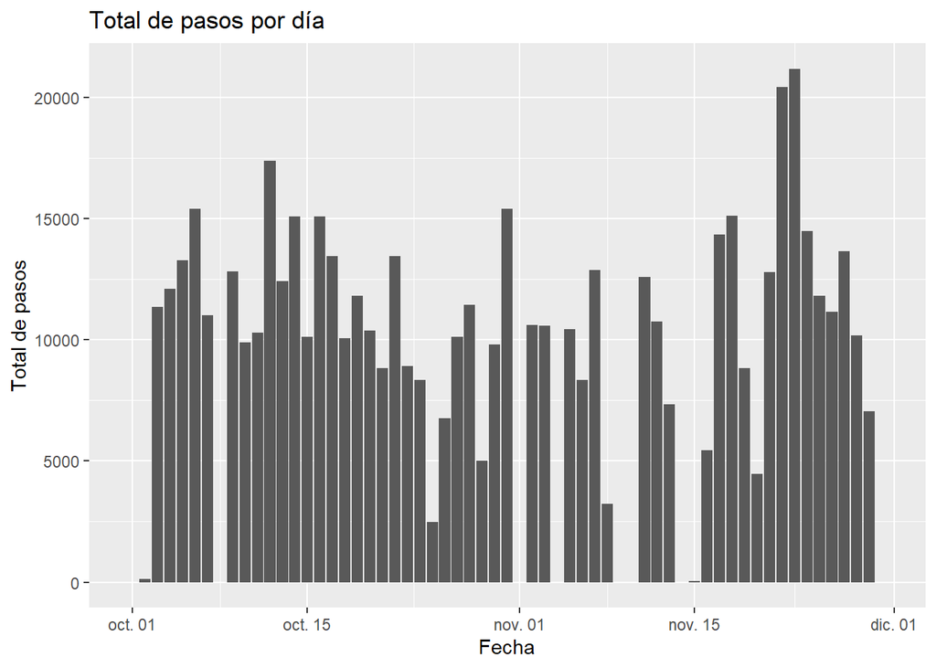

```r
ggplot(stepsday,aes(y=sumsteps,x=date))+
      geom_bar(stat="identity")+
      ylab("Total de pasos")+
      xlab("Fecha")+
      ggtitle("Total de pasos por día")
```

```r
mean.day=round(mean(stepsday$sumsteps),digits = 2)
median.day=round(median(stepsday$sumsteps),digits = 2)
```

# 3. ¿Cuál es el patrón de actividad diaria promedio?

Se crea un dataframe el cual agrupa la media de pasos dados en cada intervalo de tiempo.

```r
steps.interval=data %>%
               group_by(interval) %>%
               summarize(mean.steps = mean(steps, na.rm = TRUE))
head(steps.interval)
```

```
## # A tibble: 6 x 2
##   interval mean.steps
##      <int>      <dbl>
## 1        0     1.72
## 2        5     0.340
## 3       10     0.132
## 4       15     0.151
## 5       20     0.0755
## 6       25     2.09
```

Se muestra la grafica de tipo 1 del conjunto de datos steps.interval.

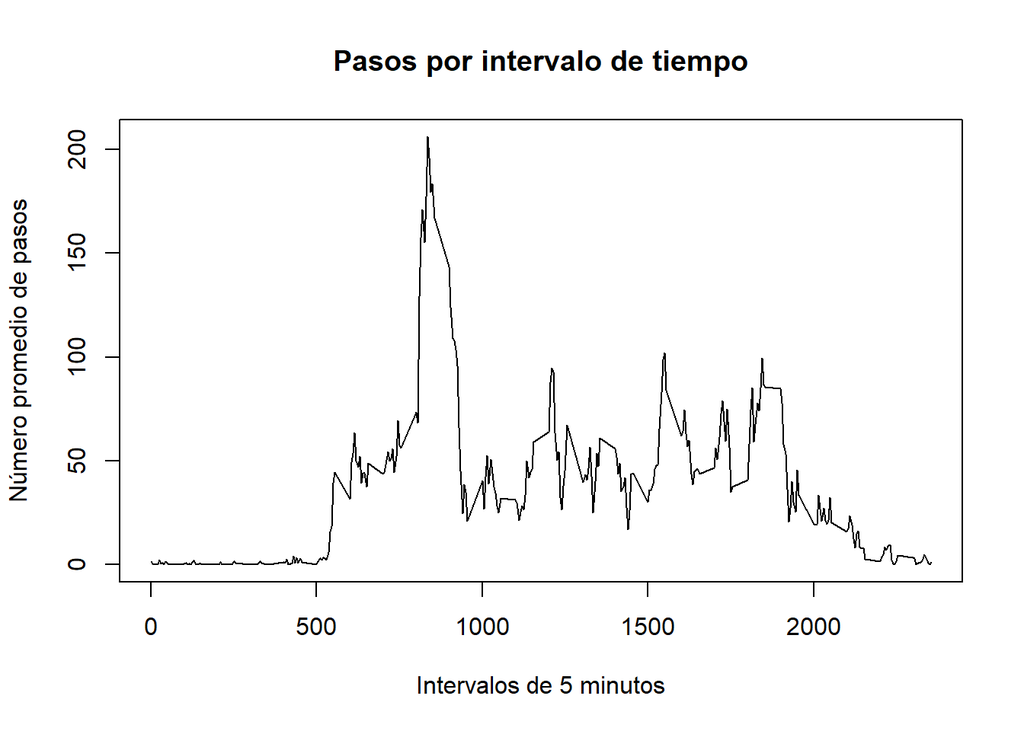

```r
plot(steps.interval$mean.steps ~ steps.interval$interval,
     col="black", type="l", xlab = "Intervalos de 5 minutos",
     ylab = "Número promedio de pasos",
     main = "Pasos por intervalo de tiempo")
```

Se calcula el intervalo con la mayor cantidad de pasos.

```r
interval=steps.interval$interval[which.max(steps.interval$mean.steps)]
numstps=round(max(steps.interval$mean.steps),digits=2)
```

El intervalos con la mayor cantidad de pasos es 835, y el número de pasos en el intervalo es de 206.17 .

# 4. Imputación de valores perdidos

Ahora miraremos la cantidad de datos N.A (falatantes).

```r
numNA=sum(is.na(data$steps))
```

La cantidad de datos faltantes es 2304.  
Una estrategia para reemplazar los datos falatantes, es tomar la media de pasos dados en el intervalo correspondiente del dato faltante, para este hecho crearemos un nuevo dataframe donde se almacenará estos nuevos datos.

```r
new.data=data
for (i in 1:nrow(data)){
        if(is.na(data$steps[i])){
                new.data$steps[i]=steps.interval$mean.steps[new.data$interval[i]==steps.interval$interval]
        }
}
head(new.data)
```

```
##       steps       date interval
## 1 1.7169811 2012-10-01        0
## 2 0.3396226 2012-10-01        5
## 3 0.1320755 2012-10-01       10
## 4 0.1509434 2012-10-01       15
## 5 0.0754717 2012-10-01       20
## 6 2.0943396 2012-10-01       25
```

Este nuevo conjunto de datos tambien se puede agrupar por día, y ver la cantidad de pasos por día.

```r
new.stepsday=data.frame()
new.stepsday=new.data %>%
        group_by(date) %>%
        summarize(sumsteps = sum(steps, na.rm = TRUE))
head(new.stepsday)
```

```
## # A tibble: 6 x 2
##   date       sumsteps
##   <date>        <dbl>
## 1 2012-10-01   10766.
## 2 2012-10-02     126
## 3 2012-10-03   11352
## 4 2012-10-04   12116
## 5 2012-10-05   13294
## 6 2012-10-06   15420
```

Se muestra a continuación un histograma del nuevo conjunto de datos.

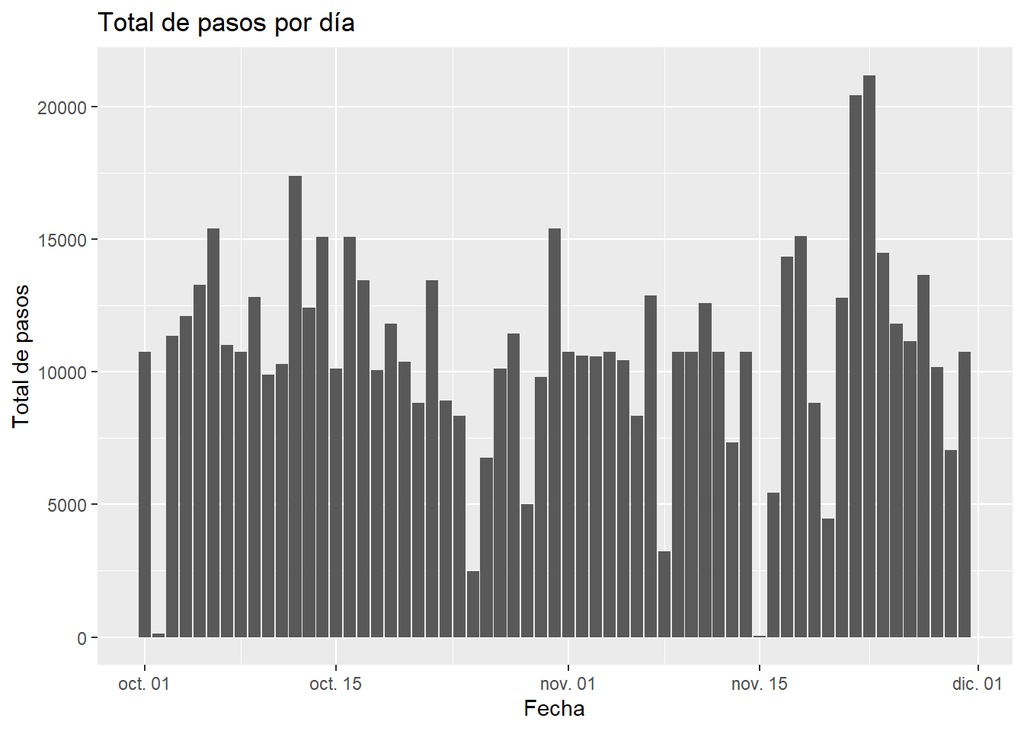

```r
ggplot(new.stepsday,aes(y=sumsteps,x=date))+
       geom_bar(stat="identity")+
       ylab("Total de pasos")+
       xlab("Fecha")+
       ggtitle("Total de pasos por día")
```

```r
new.mean.day=round(mean(new.stepsday$sumsteps),digits = 4)
new.median.day=round(median(new.stepsday$sumsteps),digits = 4)
```

# 5. ¿Existen diferencias en los patrones de actividad entre los días de semana y los fines de semana?

```r
data.dayweek=new.data
data.dayweek$date=as.Date(data.dayweek$date)
#crea un factor dependiendo si es dia entre semana o fin de semana
data.dayweek$day=ifelse(weekdays(data.dayweek$date) %in% c("sabado", "domingo"), "weekend", "weekday")
data.dayweek$day=as.factor(data.dayweek$day)
```

Luego filtraremos por separado los dias “weekend” y “weekday”".

```r
Weekday=filter(data.dayweek, data.dayweek$day == "weekday")
Weekend=filter(data.dayweek, data.dayweek$day == "weekend")
```

Ahora por separado, cada dataframe se agrupará la media de pasos por intervalo de tiempo. Y despues estos dos conjuntos formaran uno solo.

```r
Weekday=Weekday %>%
        group_by(interval) %>%
        summarize(steps = mean(steps))
Weekday$day="weekday"

head(Weekday)
```

```
## # A tibble: 6 x 3
##   interval  steps day
##      <int>  <dbl> <chr>
## 1        0 1.94   weekday
## 2        5 0.384  weekday
## 3       10 0.150  weekday
## 4       15 0.171  weekday
## 5       20 0.0854 weekday
## 6       25 1.39   weekday
```

```r
Weekend=Weekend %>%
        group_by(interval) %>%
        summarize(steps = mean(steps))
Weekend$day="weekend"

head(Weekend)
```

```
## # A tibble: 6 x 3
##   interval   steps day
##      <int>   <dbl> <chr>
## 1        0 0.215   weekend
## 2        5 0.0425  weekend
## 3       10 0.0165  weekend
## 4       15 0.0189  weekend
## 5       20 0.00943 weekend
## 6       25 6.76    weekend
```

```r
wkdayWkend=rbind(Weekday, Weekend)
wkdayWkend$day=as.factor(wkdayWkend$day)
```

Con el conjunto de datos “wkdayWkend” se procede a realizar la siguiente grafica.

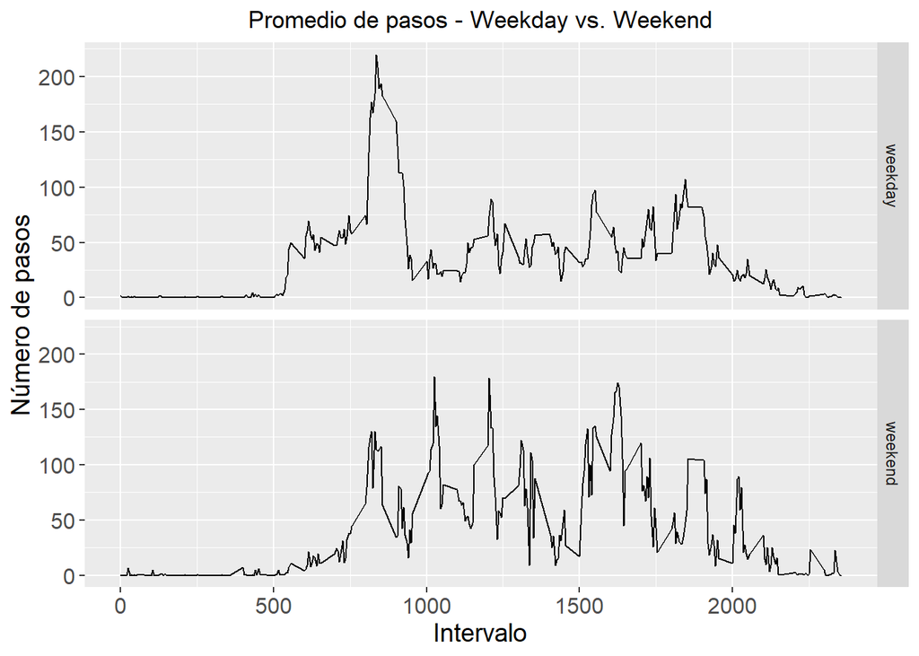

```r
g <- ggplot (wkdayWkend, aes (interval, steps))
g + geom_line() + facet_grid (day~.) +
        theme(axis.text = element_text(size = 12),axis.title = element_text(size = 14)) +
        labs(y = "Número de pasos") + labs(x = "Intervalo") +
        ggtitle("Promedio de pasos - Weekday vs. Weekend") +
        theme(plot.title = element_text(hjust = 0.5))
```

Fin del analisis.